# Introdução à Estatística Multivariada

## Análise Estatística Multivariada

- A capacidade de coleta e armazenamento de dados tem aumentado significativamente ao longo do tempo, tornando cada vez maior a quantidade de informações (variáveis) que se dispõe sobre cada indivíduo.
- Assim, tem-se a necessidade de transformar essa grande quantidade de dados em conhecimento, que possa fundamentar a compreensão de diferentes fenômenos e subsidiar tomadas de decisões.
- Nesse contexto, técnicas de análise de dados que permitam explorar e compreender as relações existentes entre múltiplas variáveis tornam-se essenciais na análise

## Definição de Análise Multivariada

**Análise Multivariada**

A análise multivariada contempla um conjunto de métodos estatísticos utilizados na análise conjunta de múltiplas variáveis avaliadas nos indivíduos sob estudo.

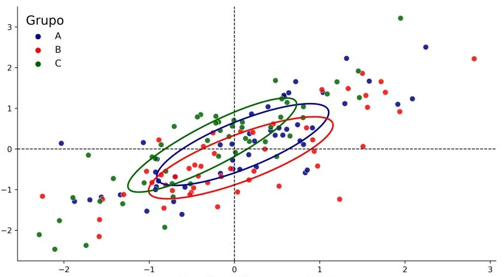

## Principais objetivos da Análise Multivariada

Métodos de Análise Multivariada podem ser aplicados para diversas finalidades, dentre as quais podemos destacar:

- Redução ou simplificação de dados;
- Classificação;
- Agrupamento;
- dentre outros…

## Exemplos de aplicações

- **Redução ou simplificação de dados**
  - Dados referentes aos sintomas de determinada doença e limitações relatadas pelos pacientes, decorrentes da doença ou do tratamento, podem ser usados para a elaboração de um índice de qualidade de vida;
  - Diferentes indicadores demográficos e sócio-econômicos podem ser usados para a elaboração de um gráfico, em duas dimensões, em que proximidade entre pontos (representando bairros de um município, por exemplo) configure similaridade entre eles.

## Exemplos de aplicações

- **Agrupamento**
  - Dados cadastrais podem ser utilizados com o objetivo de definir grupos de clientes de uma loja de departamentos similares quanto a informações disponíveis em suas fichas;
  - Variáveis referentes à contabilidade de indústrias no último ano (gastos com mão de obra, investimento em matéria prima, produção…) podem ser usadas para agrupá-las em clusters de indústrias com características contábeis similares.

## Exemplos de aplicações

- **Classificação**
  - Resultados de diversas variáveis psicológicas e comportamentais podem ser usados para criar uma regra de discriminação de usuários de drogas que reincidem, após período de abstinência, daqueles que não reincidem;
  - Variáveis referentes à anatomia de moscas (comprimento de asas, peso, coloração…) podem ser usadas para discriminar moscas em uma de quatro espécies distintas segundo os valores apresentados para tais variáveis.

## Disposição dos dados em uma análise multivariada

- Numa análise multivariada, dispõe-se, em geral, de uma amostra de $n$ indivíduos, com $p > 1$ variáveis avaliadas em cada um deles.
- O uso de técnicas multivariadas permite analisar simultaneamente as $p$ variáveis.
- Os métodos multivariados consistem, muitas vezes, de generalizações de procedimentos univariados utilizados para fins semelhantes.

## Disposição dos dados em uma análise multivariada

- Vamos denotar por $x_{ij}$ o valor da variável $j$ verificado no indivíduo $i$, $i = 1, 2, \cdots, n$; $j = 1, 2, \cdots, p$.
- A disposição usual dos dados é na forma convencional, entrando com os indivíduos nas linhas e as variáveis nas colunas.

|  | Var 1 | Var 2 | $\cdots$ | Var j | $\cdots$ | Var p |
| --- | --- | --- | --- | --- | --- | --- |
| Ind 1 | $x_{11}$ | $x_{12}$ | $\cdots$ | $x_{1j}$ | $\cdots$ | $x_{1p}$ |
| Ind 2 | $x_{21}$ | $x_{22}$ | $\cdots$ | $x_{2j}$ | $\cdots$ | $x_{2p}$ |
| $\vdots$ | $\vdots$ | $\vdots$ | $\vdots$ | $\vdots$ | $\vdots$ | $\vdots$ |
| Ind i | $x_{i1}$ | $x_{i2}$ | $\cdots$ | $x_{ij}$ | $\cdots$ | $x_{ip}$ |
| $\vdots$ | $\vdots$ | $\vdots$ | $\cdots$ | $\vdots$ | $\cdots$ | $\vdots$ |
| Ind n | $x_{n1}$ | $x_{n2}$ | $\cdots$ | $x_{nj}$ | $\cdots$ | $x_{np}$ |

## Representação matricial dos dados

- Para fins de apresentação e desenvolvimento da teoria, a representação matricial dos dados é necessária.
- A matriz dos dados tem dimensão $n \times p$, apresentando nas linhas os $n$ indivíduos e nas colunas as $p$ variáveis.

$$\mathbf{X}_{n \times p} = \left[ \begin{array}{cccc} x_{11} & x_{12} & \cdots & x_{1p} \\ x_{21} & x_{22} & \cdots & x_{2p} \\
\vdots & \vdots & \ddots & \vdots \\ x_{n1} & x_{n2} & \cdots & x_{np} \end{array} \right]$$

## Vetores aleatórios

- Para o tratamento probabilístico de dados multivariados, vamos relembrar a definição de vetor aleatório.
- Um vetor aleatório de dimensão $p$ é um vetor em que cada um de seus $p$ componentes é uma variável aleatória.
- Vamos denotar um vetor aleatório $\mathbf{x}$ por $\mathbf{x} = (X_1, X_2, \cdots, X_p)^t$. A função distribuição de probabilidade conjunta de $\mathbf{x}$ é definida como:

$$F(\mathbf{x}) = P(X_1 \leqslant x_1, X_2 \leqslant x_2, \cdots, X_p \leqslant x_p)$$

para $\mathbf{x} \in \mathbb{R}^p$

## Vetores aleatórios

- Se $\mathbf{x}$ for contínua, então a função densidade de probabilidade $f(\mathbf{x})$ fica definida por:

$$f(\mathbf{x}) = \dfrac{\partial F(\mathbf{x})}{\partial x_1 \partial x_2 \cdots \partial x_p},$$

satisfazendo

$$\int \limits_{-\infty}^{\infty} \int \limits_{-\infty}^{\infty} \cdots \int \limits_{-\infty}^{\infty} f(x_1, x_2, \cdots, x_p)dx_1 dx_2 \cdots dx_p = 1$$

## Vetores aleatórios

e,

$$f(x_1, x_2, \cdots, x_p) \geqslant 0$$

para qualquer conjunto de valores $x_1, x_2, \cdots, x_p$.

## Vetores aleatórios

- Cada elemento de $\mathbf{x} = (X_1, X_2, \cdots, X_p)^t$ é uma variável aleatória $X_i$, $i = 1, 2, \cdots, p$, cuja distribuição (denominada distribuição marginal) fica determinada pela função densidade de probabilidade $f(x_i)$:

$$f(x_i) = \int \limits_{x_1} \int \limits_{x_2} \cdots \int \limits_{x_p} f(\mathbf{x})dx_1 dx_2 \cdots dx_p, \,\,\,\, j \neq i$$

- Se $X_1, X_2, \cdots, X_p$ forem independentes, então:

$$f(x_1, x_2, \cdots, x_p) = \prod \limits_{i=1}^p f(x_i) = f(x_1) f(x_2) \cdots f(x_p)$$

## Vetores aleatórios

- A média e a variância de $X_i$, ficam definidas como:

$$\mu_i = E(X_i) = \int \limits_{-\infty}^{\infty} x_i f(x_i)dx_i$$

$$\sigma_{ii} = Var(X_i) = \int \limits_{-\infty}^{\infty} (x_i - \mu_i)^2 f(x_i)dx_i$$

para $i = 1, 2, \cdots, p$.

## Vetores aleatórios

- Para duas variáveis aleatórias $X_i$ e $X_j$, a covariância é um parâmetro da distribuição conjunta bivariada que mede a associação linear entre elas:

$$\sigma_{ij} = Cov(X_i, X_j) = \int \limits_{-\infty}^{\infty} \int \limits_{-\infty}^{\infty} (x_i - \mu_i)(x_j - \mu_j) f(x_i, x_j)dx_idx_j$$

- Se $X_i$ e $X_j$ forem independentes, então $Cov(X_i, X_j ) = 0$.

## Vetores aleatórios

- O coeficiente de correlação de $X_i$ e $X_j$ é definido como:

$$\rho_{ij} = \dfrac{\sigma_{ij}}{\sigma_i \sigma_j}$$

sendo uma medida de associação linear adimensional, tal que $-1 \leqslant \rho \leqslant 1$.

- Todos os resultados equivalentes para o caso discreto são obtidos substituindo adequadamente as integrais por somas.

## Vetores aleatórios

- A esperança matemática de um vetor aleatório $\mathbf{x} = (X_1, X_2, \cdots, X_p)^t$ é definida pelo vetor de mesma dimensão em que cada elemento corresponde à esperança matemática da respectiva variável.

$$\mathbf{\mu} = E(\mathbf{x}) = E \left( \left[ \begin{array}{c} X_{1} \\ X_{2} \\ \vdots
\\ X_{p} \end{array} \right] \right) = \left[ \begin{array}{c} E(X_{1}) \\ E(X_{2}) \\ \vdots
\\ E(X_{p}) \end{array} \right] = \left[ \begin{array}{c} \mu_1 \\ \mu_2 \\ \vdots
\\ \mu_p \end{array} \right]$$

## Vetores aleatórios

- A matriz de variâncias e covariâncias de um vetor aleatório $\mathbf{x} = (X_1, X_2, \cdots, X_p)^t$ é definida pela matriz $\mathbf{\Sigma}$ dada por:

$$\begin{eqnarray*} \mathbf{\Sigma} &=& E \left[(\mathbf{x} - \mathbf{\mu})(\mathbf{x} -
\mathbf{\mu})^t \right] \\ &=&
\left[ \begin{array}{ccc} E(X_1 - \mu_1)^2 & \cdots & E(X_1 - \mu_1)( X_p - \mu_p) \\ E(X_2 - \mu_2)(X_1 - \mu_1) & \cdots & E(X_2 - \mu_2)( X_p - \mu_p)\\ \vdots & \ddots & \vdots \\ E( X_p - \mu_p)(X_1 - \mu_1) & \cdots & E( X_p - \mu_p)^2 \end{array} \right]
\end{eqnarray*}$$

## Vetores aleatórios

- De maneira semelhante, a matriz de correlações do vetor aleatório $\mathbf{x}$ fica dada por:

$$\mathbf{P} = \left[ \begin{array}{cccc} 1 & \rho_{12} & \cdots & \rho_{1p} \\ \rho_{21} & 1 & \cdots & \rho_{2p}\\ \vdots & \vdots & \ddots & \vdots \\ \rho_{p1} & \rho_{p2} & \cdots & 1
\end{array} \right]$$

## Vetores aleatórios

- A matriz de correlações pode ser determinada facilmente a partir da matriz de covariâncias por:

$$\mathbf{P} = \left(\mathbf{V}^\frac{1}{2}\right)^{-1} \mathbf{\Sigma} \left(\mathbf{V}^\frac{1}{2}\right)^{-1}$$

sendo $\mathbf{V}^\frac{1}{2}$ a matriz diagonal com elementos $\sqrt{\sigma_{11}}, \sqrt{\sigma_{22}}, \cdots, \sqrt{\sigma_{pp}}$.

## Propriedades da média e da variância de vetores aleatórios

- Sejam $\mathbf{A}$ e $\mathbf{B}$ matrizes matrizes e $c$ um vetor de constantes (todos com dimensões compatíveis às operações apresentadas). Sejam $\mathbf{x}$ e $\mathbf{y}$ vetores aleatórios.
  - $E(\mathbf{x} + \mathbf{y}) = E(\mathbf{x}) + E(\mathbf{y})$;
  - $E(\mathbf{AxB}) = \mathbf{A} E(\mathbf{x}) \mathbf{B}$;
  - $E(\mathbf{Ax} + c) = \mathbf{A} E(\mathbf{x}) + c$;
  - $Cov(\mathbf{x}) = E(\mathbf{x} \mathbf{x}^t) - \mathbf{\mu}_x \mathbf{\mu}_x^t$;
  - $Cov(c^t \mathbf{x}) = c^t Cov(\mathbf{x})c$;
  - $Cov(\mathbf{A}^t \mathbf{x} + c) = \mathbf{A} Cov(\mathbf{x})\mathbf{A}^t$.

## Descrição de dados multivariados

- Na prática, todas as matrizes teóricas ( $\mathbf{\mu}$, $\mathbf{\Sigma}$, $\mathbf{P}$ e $\mathbf{V}$ ) são desconhecidas e precisam ser estimadas através de dados amostrais.
- Seja então, uma amostra aleatória multivariada de tamanho $n$.
- Podemos calcular a média amostral separadamente para cada variável:

$$\bar{x}_j = \dfrac{1}{n} \sum \limits_{i=1}^n x_{ij}, \,\,\,\,\,\, j = 1, 2, \cdots, p$$

## Descrição de dados multivariados

- O vetor de médias amostrais fica definido por:

$$\bar{\mathbf{x}} = \left[ \begin{array}{c} \bar{x}_1 \\ \bar{x}_2\\ \vdots \\ \bar{x}_p \end{array} \right]$$

- Matricialmente, temos $\bar{\mathbf{x}} = \dfrac{1}{n} \mathbf{X}^t \mathbf{j}$, sendo $\mathbf{X}$ a matriz de dados e $\mathbf{j}$ o vetor de 1’s de dimensão $n$.

## Descrição de dados multivariados

- A variância amostral para a $j$-ésima variável e a covariância amostral para as variáveis $X_j$ e $X_k$ são definidas, respectivamente, por:

$$s_{jj} = \frac{\displaystyle\sum _{i=1}^n (x_{ij}-\bar{x_j})^2}{n-1}$$

$$s_{jk} = \frac{\displaystyle\sum _{i=1}^n (x_{ij}-\bar{x_j})(x_{ik}-\bar{x_k})}{n-1}, \hspace{0.5cm} j \neq k$$

## Descrição de dados multivariados

- A matriz de covariâncias amostral (simétrica) fica definida por:

$$\mathbf{S}_{p \times p} = \left[ \begin{array}{cccc} s_{11} & s_{12} & \cdots & s_{1p} \\ s_{21} & s_{22} & \cdots & s_{2p}\\ \vdots & \vdots & \ddots & \vdots \\ s_{p1} & s_{p2} & \cdots & s_{pp} \end{array} \right]$$

## Descrição de dados multivariados

- Podemos expressar a matriz de covariâncias em termos dos vetores observados:

$$\mathbf{S} = \dfrac{1}{n-1} \sum \limits_{i=1}^n (\mathbf{x}_i - \bar{\mathbf{x}})(\mathbf{x}_i - \bar{\mathbf{x}})^t = \dfrac{1}{n-1} \left( \sum \limits_{i=1}^n \mathbf{x}_i \mathbf{x}_i^t - n \bar{\mathbf{x}}\bar{\mathbf{x}}^t \right)$$

## Descrição de dados multivariados

- O coeficiente de correlação amostral entre as variáveis $X_j$ e $X_k$ é dado por:

$$r_{jk} = \dfrac{s_{jk}}{\sqrt{s_{jj}} \sqrt{s_{kk}}} = \dfrac{\sum \limits_{i=1}^n (x_{ij} - \bar{x}_j)(x_{ik} - \bar{x}_k)}{\sqrt{\sum \limits_{i=1}^n (x_{ij} - \bar{x}_j)^2} \sqrt{\sum \limits_{i=1}^n (x_{ik} - \bar{x}_k)^2}}$$

## Descrição de dados multivariados

- A matriz de correlações amostrais (simétrica) é determinada pelos coeficientes calculados para cada par de variáveis.

$$\mathbf{R}_{p \times p} = \left[ \begin{array}{cccc} 1 & r_{12} & \cdots & r_{1p} \\
r_{21} & 1 & \cdots & r_{2p}\\
\vdots & \vdots & \ddots & \vdots \\
r_{p1} & r_{p2} & \cdots & 1
\end{array} \right]$$

## Descrição de dados multivariados

- Como complemento às medidas descritivas apresentadas, o uso de gráficos permite extrair informações importantes dos dados. Alguns gráficos (e recursos adicionais):
  - Histograma;
  - Boxplot;
  - Diagrama de dispersão;
  - Correlograma;
  - Matrizes de gráficos;
  - Faces de Chernoff;
  - Gráficos tridimensionais…

## Variância generalizada e variância total

- Em algumas situações, é de interesse exprimir a varição presente nos dados multivariados em um único valor.
- Uma das alternativas para isso é a **variância generalizada**, que é definida como o determinante da matriz de covariâncias amostral.

$$\text{Variância generalizada} = |\mathbf{S}|$$

- Naturalmente, por resumir toda a variação em um único valor, parte da informação referente à variação dos dados se perde nesse resumo, originando possíveis distorções.

## Variância generalizada e variância total

- A variância generalizada pode ser definida ainda a partir das variáveis originais padronizadas $(x_{ij} - \bar{x}_j)/s_{jj}$, contornando problema de diferentes escalas das variáveis. Como resultado da padronização, temos:

$$\text{Variância generalizada das variáveis padronizadas} = |\mathbf{R}|$$

## Variância generalizada e variância total

- Algumas propriedades da variância generalizada:
  - Quanto maior a variância de uma variável, maior sua contribuição para a variância generalizada;
  - Quanto maior a correlação entre duas variáveis, menor a variância generalizada;
  - Caso duas ou mais variáveis sejam perfeitamente correlacionadas a variância generalizada atingirá seu mínimo valor (zero);
  - A variância generalizada será máxima caso as variáveis tenham correlação nula.

## Variância generalizada e variância total

- Uma das limitações da variância generalizada é o fato de diferentes estruturas de correlação produzirem, algumas vezes, igual variância generalizada.
- **Exemplo:** Calcular, para cada matriz de covariâncias, a variância generalizada e a correlação entre as variáveis.

$$\mathbf{S}_1 = \left[ \begin{array}{rr} 10 & 8 \\ 8 & 10 \end{array} \right], \,\,\,\,\,\,\,\, \mathbf{S}_2 = \left[ \begin{array}{rr} 10 & -8 \\ -8 & 10 \end{array} \right], \,\,\,\,\,\,\,\, \mathbf{S}_3 = \left[ \begin{array}{rr} 9 & 0 \\ 0 & 4 \end{array} \right]$$

## Variância generalizada e variância total

- Outra medida usada para resumir a variação total em um único valor é a **variância total**, definida por:

$$\text{Variância total} = \text{tr}(\mathbf{S}) = s_{11} + s_{22} + \cdots + s_{pp}$$

- Por se basear apenas na diagonal de $\mathbf{S}$, a variância total claramente ignora a estrutura de correlação dos dados.

## Distâncias

- Boa parte das técnicas multivariadas baseiam-se no conceito de distância.
- Usamos distâncias para medir quão semelhantes são dois indivíduos com relação aos valores observados para $p$ variáveis.
- Sejam dois vetores $\mathbf{x}$ e $\mathbf{y} \in \mathbb{R}^p$ e uma matriz $\mathbf{\Psi}$, positiva definida. Então, a expressão geral para a distância quadrática entre os vetores $\mathbf{x}$ e $\mathbf{y}$ é dada por:

$$d^2(\mathbf{x}, \mathbf{y}) = \left| \mathbf{x} - \mathbf{y} \right|^2_{\mathbf{\Psi}} = (\mathbf{x} - \mathbf{y})^t{\mathbf{\Psi}} (\mathbf{x} - \mathbf{y})$$

em que a matriz $\mathbf{\Psi}$, positiva definida, é chamada de métrica.

## Distâncias

- Consideremos agora $\mathbf{z}$, um terceiro vetor de $\mathbb{R}^p$. Então as seguintes propriedades são válidas:
  - $d(\mathbf{x}, \mathbf{y}) = d(\mathbf{y}, \mathbf{x})$
  - $d(\mathbf{x}, \mathbf{y}) > 0 \hspace{0.5cm} \forall \hspace{0.2cm} \mathbf{x} \neq \mathbf{y}$
  - $d(\mathbf{x}, \mathbf{y}) = 0 \hspace{0.5cm} \text{se, e somente se,} \hspace{0.5cm} \mathbf{x} = \mathbf{y}$
  - $d(\mathbf{x}, \mathbf{y}) \leq d(\mathbf{x}, \mathbf{z}) + d(\mathbf{y}, \mathbf{z}) \,\,\,\,\,\, \text{(desigualdade triangular)}$
- Dependendo da escolha da métrica $\mathbf{\Psi}$, podemos obter diferentes medidas de distâncias, cada uma com suas características e aplicações. A escolha de uma medida adequada é fundamental para qualquer análise.

## Distância Euclidiana

- Se a métrica $\mathbf{\Psi}$ é dada por $\mathbf{\Psi} = \mathbf{I}$, temos a **distância euclidiana quadrática**. Neste caso, a expressão da distância é dada por:

$$d^2(\mathbf{x}, \mathbf{y}) = (\mathbf{x} - \mathbf{y})^t (\mathbf{x} - \mathbf{y})$$

de forma que a **distância euclidiana** é dada por:

$$d(\mathbf{x}, \mathbf{y}) = \sqrt{(\mathbf{x} - \mathbf{y})^t (\mathbf{x} - \mathbf{y})}$$

## Distância Euclidiana

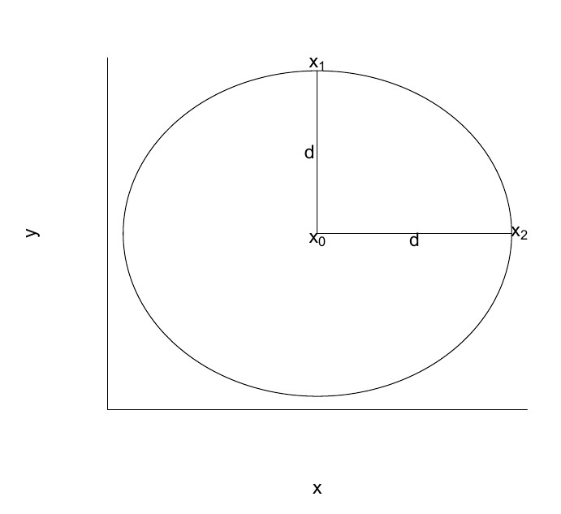

## Distância Euclidiana

- A distância euclidiana confere mesmos pesos às diferenças verificadas em cada uma das $p$ dimensões.
- Nas análises estatísticas, em que distâncias serão aplicadas a dados de variáveis com diferentes variâncias, e na presença de covariâncias, incorporar tais características ao cálculo da distância pode ser fundamental.
- Nesse contexto, duas medidas de distância mais apropriadas são as distâncias de **Karl Pearson** e a de **Mahalanobis**.

## Distância de Karl Pearson

- Se considerarmos a métrica $\mathbf{\Psi}$ como sendo igual a

$$\mathbf{\Psi} = \mathbf{D}^{-1} = \text{diag}\left(\dfrac{1}{s_{kk}}\right), \hspace{1cm} k = 1,\cdots, p,$$

então podemos definir a **distância quadrática de Karl Pearson** por:

$$d^2_p(\mathbf{x}, \mathbf{y}) = (\mathbf{x} - \mathbf{y})^t \mathbf{D}^{-1}(\mathbf{x} - \mathbf{y})$$

de forma que a distância euclidiana ponderada é dada por,

$$d_p(\mathbf{x}, \mathbf{y}) = \sqrt{(\mathbf{x} - \mathbf{y})^t\mathbf{D}^{-1} (\mathbf{x} - \mathbf{y})}$$

## Distância de Karl Pearson

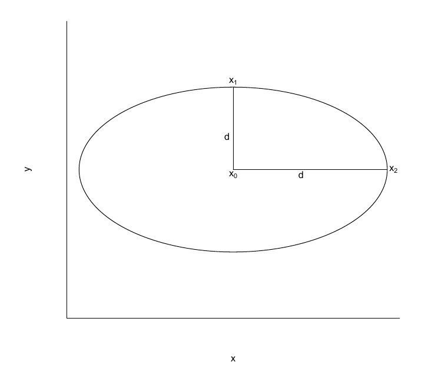

## Distância de Karl Pearson

- A distância de Karl Pearson evita o problema de heterogeneidade em um sistema de variáveis é dividindo cada variável por um fator que elimine o fator escala.
- Também é conhecida como distância euclidiana ponderada ou padronizada

## Distância de Mahalanobis

- A **distância de Mahalanobis** configura um caso mais geral, em que são usadas tanto as variâncias quanto as covariâncias no cálculo da distância.
- Se considerarmos a métrica $\mathbf{\Psi}$ igual a $\mathbf{\Psi} = \mathbf{S}^{-1}$, temos a chamada **distância quadrática de Mahalanobis**, dada por:

$$d^2_M(\mathbf{x}, \mathbf{y}) = (\mathbf{x} - \mathbf{y})^t \mathbf{S}^{-1}(\mathbf{x} - \mathbf{y})$$

de forma que a distância de Mahalanobis é dada por,

$$d_M(\mathbf{x}, \mathbf{y}) = \sqrt{(\mathbf{x} - \mathbf{y})^t\mathbf{S}^{-1} (\mathbf{x} - \mathbf{y})}$$

## Distância de Mahalanobis

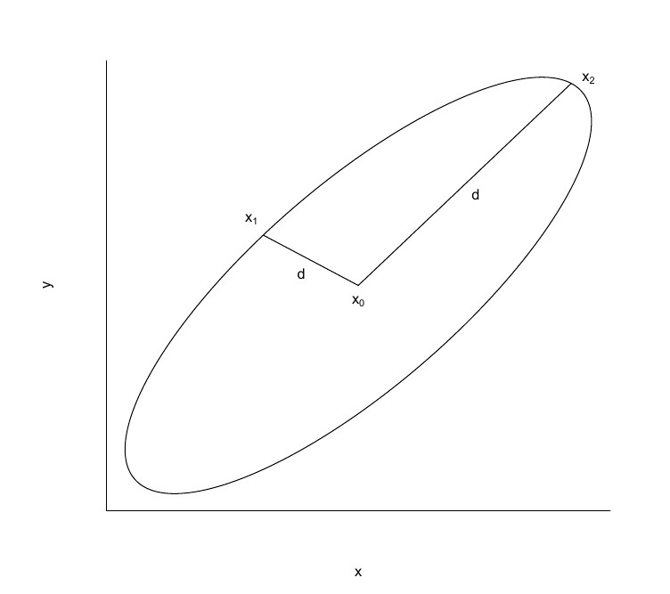

## Distância de Mahalanobis

- A distância de Mahalanobis é largamente aplicada, permitindo acomodar diferentes escalas e correlações entre as variáveis.
- Dada sua definição, a distância de Mahalanobis, ao incorporar a inversa da matriz de covariância, tem como efeitos:
  - Padronizar todas as variáveis de forma que apresentem mesma variância;
  - Eliminar correlações.

## Matriz de distâncias

- Seja qual for a distância utilizada, é comum, em análises multivariadas, calculá-la para cada par de indivíduos e armazenar os valores em uma matriz, denominada **matriz de distâncias**.

$$\mathbf{D}_{n \times n} = \left[ \begin{array}{cccc} 0 & d_{12} & \cdots & d_{1n} \\ d_{21} & 0 & \cdots & d_{2n}\\ \vdots & \vdots & \ddots & \vdots \\ d_{n1} & d_{n2} & \cdots & 0 \end{array} \right]$$

em que $d_{ij} = d_{ji}$ é a distância calculada para os indivíduos $i$ e $j$, utilizando uma métrica qualquer.

- A visualização das distâncias num gráfico do tipo “mapa de calor” permite uma apreciação conjunta das distâncias calculadas duas a duas.